# Figure-2

# Fig 2a and 2b

We downloaded the RepliSeq measurements (as wavelet-smoothed signal, ile SM923451_hg19_wgEncodeUwRepliSeqGm12878WaveSignalRep1.bigWig) of 11 ENCODE cell lines (SK-N-SH = neuroblastoma; MCF-7 = mammary gland adenocarcinoma; BJ = skin fibroblast; NHEK = epidermal keratinocytes; HepG2 = liver carcinoma; IMR90 = fetal lung fibroblasts; K562 = leukemia; HeLa-S3 = cervical carcinoma; GM12878 = lymphoblastoid; HUVEC = umbilical vein endothelial cells; BG02ES = embryonic stem cell; ) from the UCSC Genome Browser (also available in NCBI GEO as GSE34399). To avoid biasing the sample, we excluded multiple lymphoblastoid cell lines and retained Gm12878 as a representative, which was previously described in [Differential DNA mismatch repair underlies mutation rate variation across the human genome] and [Sequencing newly replicated DNA reveals widespread plasticity in human replication timing]. We computed the average RepliSeq signal within 1Mb genome windows of the remaining 11 cell lines (cross-tissue replication timing signal), having resulting values that ranged from 0-100, where higher values indicate earlier replication.

**Creating the 1 MB windows**:

First the exon coding regions where extracted using the [UCSC browser](http://genome.ucsc.edu/cgi-bin/hgTables?command=start), options track: UCSC Genes; table: knownGene; output format: BED - browser extensible data; option Exons. Then using bedtools we masked blacklisted regions defined by Anshul Kundage and Duke [bed file here](http://genome.ucsc.edu/cgi-bin/hgTrackUi?hgsid=876251189_lEwmtar4Jcr1MJgh92cL5gL9Anaa&g=wgEncodeDacMapabilityConsensusExcludable). Then we generated 1 Mb windows covering all the genome and calculated the effective exonic length (EEL) within each window for determining SNS densities (SNV counts in each window multiplied the by EEL fraction) to get SNS per MB. Furthermore, replication timing is known to be organized in megabase-scale domains.

**Calculations:**

```r
###Calculations for Replication timing..
bed_exonCoding<-import("Data/Figure2/Raw_Calculations/bedfilesForBins/bedfilesForBins/codingExons_hg19_NOblacklist.bed")
bed_exonCoding
seqnames(bed_exonCoding)
tmp<-as.data.frame(bed_exonCoding)
table(tmp$seqnames)
paste0("chr",seq(1,22,1))
bed_exonCoding<-keepSeqlevels(bed_exonCoding,c(paste0("chr",seq(1,22,1)),"chrX"),pruning.mode="coarse")
seqnames(bed_exonCoding)
bed_exonCoding
GenomeInfoDb::seqlengths(bed_exonCoding)
require(GenomicRanges)
require(ggbio)
require(BSgenome.Hsapiens.UCSC.hg19)

chr.lengths = seqlengths(Hsapiens)[1:23]
names(chr.lengths)<-c(paste0("chr",seq(1,22,1)),"chrX")
chr.lengths
seqlengths(bed_exonCoding)<-chr.lengths
bed_exonCoding
seqlengths(bed_exonCoding)
bins <- GenomicRanges::tileGenome(GenomeInfoDb::seqlengths(bed_exonCoding), tilewidth=1000000, cut.last.tile.in.chrom=TRUE)
bins
seqinfo(Hsapiens)


##
#####Now import repliSeq data from each cell line, combine and get median score
# repli-seq analysis
library(rtracklayer)
library(hwglabr2)

##Import as GRanges object all the repliseq data, download from: https://www.ncbi.nlm.nih.gov/geo/query/acc.cgi?acc=GSE34399

RepliSeq_SKNSH <- import("Data/Figure2/Raw_Calculations/CellLines_repliData/GSM923441_hg19_wgEncodeUwRepliSeqSknshWaveSignalRep1.bigWig")
RepliSeq_MCF<- import("Data/Figure2/Raw_Calculations/CellLines_repliData/GSM923442_hg19_wgEncodeUwRepliSeqMcf7WaveSignalRep1.bigWig")
RepliSeq_BJ<- import("Data/Figure2/Raw_Calculations/CellLines_repliData/GSM923444_hg19_wgEncodeUwRepliSeqBjWaveSignalRep2.bigWig")
RepliSeq_NHEK<- import("Data/Figure2/Raw_Calculations/CellLines_repliData/GSM923445_hg19_wgEncodeUwRepliSeqNhekWaveSignalRep1.bigWig")
RepliSeq_HEPG<- import("Data/Figure2/Raw_Calculations/CellLines_repliData/GSM923446_hg19_wgEncodeUwRepliSeqHepg2WaveSignalRep1.bigWig")
RepliSeq_IMR<- import("Data/Figure2/Raw_Calculations/CellLines_repliData/GSM923447_hg19_wgEncodeUwRepliSeqImr90WaveSignalRep1.bigWig")
RepliSeq_K<- import("Data/Figure2/Raw_Calculations/CellLines_repliData/GSM923448_hg19_wgEncodeUwRepliSeqK562WaveSignalRep1.bigWig")
RepliSeq_HELA<- import("Data/Figure2/Raw_Calculations/CellLines_repliData/GSM923449_hg19_wgEncodeUwRepliSeqHelas3WaveSignalRep1.bigWig")

RepliSeq_GM <- import("Data/Figure2/Raw_Calculations/CellLines_repliData/GSM923451_hg19_wgEncodeUwRepliSeqGm12878WaveSignalRep1.bigWig")
RepliSeq_HUVEC <- import("Data/Figure2/Raw_Calculations/CellLines_repliData/GSM923452_hg19_wgEncodeUwRepliSeqHuvecWaveSignalRep1.bigWig")
RepliSeq_BG <- import("Data/Figure2/Raw_Calculations/CellLines_repliData/GSM923453_hg19_wgEncodeUwRepliSeqBg02esWaveSignalRep1.bigWig")
#It contains the RepliScore for different genomic position as ranges

###Get average of RepliScore between all cellLines
###Create data frame with all values


Repli_allScores<-data.frame(S1=RepliSeq_SKNSH$score,S2=RepliSeq_MCF$score,S3=RepliSeq_BJ$score,S4=RepliSeq_NHEK$score,S5=RepliSeq_HEPG$score,S6=RepliSeq_IMR$score,S7=RepliSeq_K$score,S8=RepliSeq_HELA$score,S9=RepliSeq_GM$score,S10=RepliSeq_HUVEC$score, S11=RepliSeq_BG$score)

Repli_allScores$score_average<-matrixStats::rowMedians(as.matrix(Repli_allScores))
##Change negative values to 0
Repli_allScores$score_average<-ifelse(Repli_allScores$score_average<0, 0, Repli_allScores$score_average) #Drop values with negatives
RepliSeq_combined<-RepliSeq_SKNSH #Just to duplicate GRanges
RepliSeq_combined$score_average<-Repli_allScores$score_average
#Check distribution of repliScores
quantile(RepliSeq_combined$score_average, probs = seq(0,1,0.1))


####
# Get signal as "RleList"; the signal is stored in the "score" metadata column
RepliSeq_combined<-sort(GenomeInfoDb::sortSeqlevels(RepliSeq_combined))
score <- GenomicRanges::coverage(RepliSeq_combined, weight="score_average")
# Compute average signal per tile
RepliSeq_combined_Mb <- GenomicRanges::binnedAverage(bins, score, "average_score_Mb")
##Add extra column to say to which decile it belongs
RepliSeq_combined_Mb2<-as.data.frame(RepliSeq_combined_Mb)
RepliSeq_combined_Mb2<-RepliSeq_combined_Mb2 %>% mutate(Decile = ntile(average_score_Mb, 10)) #Use dplyr
RepliSeq_combined_Mb$Decile<-RepliSeq_combined_Mb2$Decile##Add also to the Granges object
##To know the ranges
decil_labels<-quantile(RepliSeq_combined_Mb$average_score_Mb, probs = seq(0,1,0.1))
decil_labels


#RepliSeq_combined_Mb #Same but with the Mb bins

##Import data, this is the file with all the mutations from ICGC
###We cannot provide you directly with the file due to ICGC data restrictions...
##You can generate it by running the Figure1.Rmd
icgc2_allmuts<-as.data.frame(read.delim("Data/Figure2/Raw_Calculations/icgc2_allmuts.txt")) ##Obtained from the running calculations_fig1a in the Figure1.Rmd

require(GenomicRanges)
require(ggbio)
require(BSgenome.Hsapiens.UCSC.hg19)

chr.lengths = seqlengths(Hsapiens)[1:23]
names(chr.lengths)<-c(paste0("chr",seq(1,22,1)),"chrX")
chr.lengths
###


#######
###
library(rtracklayer)
library(hwglabr2)



##To know the ranges
decil_labels<-quantile(RepliSeq_combined_Mb$average_score_Mb, probs = seq(0,1,0.1))
decil_labels

####Add data to mafcancer
dim(icgc2_allmuts)
tmp<-data.frame(Gene=icgc2_allmuts$Hugo_Symbol[],start=icgc2_allmuts$Start_Position[], stop=icgc2_allmuts$End_Position[], chrom=icgc2_allmuts$Chromosome[])
#Create data frame with mutations
tmp$chrom<-paste0("chr",tmp$chrom)#Add chr
dim(tmp)
tmp = makeGRangesFromDataFrame(df = tmp, start.field = "start", end.field = "stop", seqnames.field = "chrom",keep.extra.columns = T) # to Granges
#findOverlaps
olaps = findOverlaps(tmp, RepliSeq_combined_Mb,select = "arbitrary")  #This function gives the matrix positions for each mutation (positions at RepliSeq_combined_Mb)
#olaps<-as.data.frame(olaps)
##Add data to tmp
tmp<-as.data.frame(tmp)
tmp$average_score_Mb<-RepliSeq_combined_Mb2$average_score_Mb[olaps]
tmp$Decile<-RepliSeq_combined_Mb2$Decile[olaps]
tmp$Start_Mb<-RepliSeq_combined_Mb2$start[olaps]
tmp$End_Mb<-RepliSeq_combined_Mb2$end[olaps]
###Add to the maf file
icgc2_allmuts$Average_RepliScore_Mb<-tmp$average_score_Mb
icgc2_allmuts$RepliScore_Decile<-tmp$Decile
icgc2_allmuts$Start_Mb<-tmp$Start_Mb
icgc2_allmuts$End_Mb<-tmp$End_Mb
table(icgc2_allmuts$RepliScore_Decile)
```

```r
repli_melt_icgc<-subset(icgc2_allmuts[,c("Tumor_type","SBS.Sig.max","Tumor_Sample_Barcode","RepliScore_Decile","Start_Mb","End_Mb","Chromosome")], icgc2_allmuts$SBS.Sig.max %in% c("AICDA_canonical","SBS2","SBS13"))
dim(repli_melt_icgc)
#repli_melt$range<-paste0(repli_melt$Start_Mb,"-",repli_melt$End_Mb,"-",repli_melt$Chromosome)
repli_melt_icgc$Tumor_Sample_Barcode<-as.character(repli_melt_icgc$Tumor_Sample_Barcode)
repli_melt_icgc$Mutations<-1 #TO allow addition in next step
##Collapse summing by tumor_type the RepliScore but separating each signature
library(dplyr)
##Melt and sum, this is the mutations per megabase for each signature for each tumor type
repli_melt_icgc2<-repli_melt_icgc %>% group_by(Tumor_type, SBS.Sig.max,Start_Mb,End_Mb,Chromosome) %>% summarize(Mutations_Mb = sum(Mutations))
repli_melt_icgc2<-as.data.frame(repli_melt_icgc2)
head(repli_melt_icgc2)
dim(repli_melt_icgc2)
###Assign decil to each mutation
repli_melt_icgc2$range<-paste0(repli_melt_icgc2$Start_Mb,"-",repli_melt_icgc2$End_Mb,"-",repli_melt_icgc2$Chromosome)
RepliSeq_combined_Mb2$range<-paste0(RepliSeq_combined_Mb2$start,"-",RepliSeq_combined_Mb2$end,"-",gsub("chr","",RepliSeq_combined_Mb2$seqnames))
tmp<-match(repli_melt_icgc2$range,RepliSeq_combined_Mb2$range)
repli_melt_icgc2$RepliScore_Decile<-RepliSeq_combined_Mb2$Decile[tmp]

#repli_melt_icgc2$exonic_effective_length<-RepliSeq_combined_Mb2$exonic_effective_length[tmp] #Add exonic effective length to each range
repli_melt_icgc2$density_Mutations_Mb<-repli_melt_icgc2$Mutations_Mb
#repli_melt_icgc2$density_Mutations_Mb<-repli_melt_icgc2$Mutations_Mb/tilewidth#Adjust by percentage of tilewidth(relative to total length)
###SUm ussing deciles
repli_melt_icgc2_deciles<-repli_melt_icgc2 %>% group_by(Tumor_type, SBS.Sig.max,RepliScore_Decile) %>% summarize(Mutations_Mb_decile = sum(density_Mutations_Mb))
dim(repli_melt_icgc2_deciles)
head(repli_melt_icgc2_deciles)
repli_melt_icgc2_deciles<-as.data.frame(repli_melt_icgc2_deciles)
###Adjust data to use the mean per tumor type
##Get number of samples per tumor type
Tumor_type_number <-repli_melt_icgc[!duplicated(repli_melt_icgc$Tumor_Sample_Barcode), ]
Tumor_type_number<-table(Tumor_type_number$Tumor_type)
repli_melt_icgc2_deciles$Mutations_Mb_decile_mean<-1 #Create the column
for (i in 1:length(Tumor_type_number)) {
repli_melt_icgc2_deciles$Mutations_Mb_decile_mean<-ifelse(repli_melt_icgc2_deciles$Tumor_type==names(Tumor_type_number)[i],yes = repli_melt_icgc2_deciles$Mutations_Mb_decile/Tumor_type_number[i],repli_melt_icgc2_deciles$Mutations_Mb_decile_mean)
}


pancancer_repli_p_icgc<-ggboxplot(data = subset(repli_melt_icgc2_deciles,!is.na(RepliScore_Decile)),x ="RepliScore_Decile" , y = "Mutations_Mb_decile_mean",add = "jitter",color = "SBS.Sig.max")+ theme_classic()+geom_smooth(data=subset(repli_melt_icgc2_deciles,!is.na(RepliScore_Decile)),aes(x = RepliScore_Decile, y = Mutations_Mb_decile_mean, color=SBS.Sig.max, fill=SBS.Sig.max), size = 0.5,show.legend = F, se=FALSE)+ labs( x="Late to early replication", y = "Mutation number mean per Mb")+ guides(color=guide_legend(title = "Signature"))

##This is the Supplementary Figure  not included in the article

###Using Medians
repli_melt_icgc3<-repli_melt_icgc %>% group_by(Tumor_Sample_Barcode,Tumor_type, SBS.Sig.max,Start_Mb,End_Mb,Chromosome) %>% summarize(Mutations_Mb = sum(Mutations))
repli_melt_icgc3<-as.data.frame(repli_melt_icgc3)
head(repli_melt_icgc3)
dim(repli_melt_icgc3)
###Assign decil to each mutation
repli_melt_icgc3$range<-paste0(repli_melt_icgc3$Start_Mb,"-",repli_melt_icgc3$End_Mb,"-",repli_melt_icgc3$Chromosome)
tmp<-match(repli_melt_icgc3$range,RepliSeq_combined_Mb2$range)
repli_melt_icgc3$RepliScore_Decile<-RepliSeq_combined_Mb2$Decile[tmp]
#repli_melt_icgc3$exonic_effective_length<-RepliSeq_combined_Mb2$exonic_effective_length[tmp] #Add exonic effective length to each range
repli_melt_icgc3$density_Mutations_Mb<-repli_melt_icgc3$Mutations_Mb#*(repli_melt_icgc3$exonic_effective_length/tilewidth) #Adjust by percentage of e


###SUm ussing deciles
repli_melt_icgc3_deciles<-repli_melt_icgc3 %>% group_by(Tumor_Sample_Barcode,Tumor_type, SBS.Sig.max,RepliScore_Decile) %>% summarize(Mutations_Mb_decile = sum(density_Mutations_Mb))
dim(repli_melt_icgc3_deciles)
head(repli_melt_icgc3_deciles)
repli_melt_icgc3_deciles<-as.data.frame(repli_melt_icgc3_deciles)
repli_melt_icgc3_deciles<-subset(repli_melt_icgc3_deciles,!is.na(RepliScore_Decile))
###Graph using median and confidence intervals 95%
##The approximate 95% confidence intervals of the median (across tumour samples: Fig. 2d and Extended Data Fig. 1e,f)for the 1 Mbwindows were estimated using theformula +-1.58*IQR/ sqrt(n_samp), as defined in the R function boxplot.stats and references therein
###Create data frame with medians to be able to lauch the regression
repli_melt4_icgc<-repli_melt_icgc3_deciles %>% group_by(Tumor_type, SBS.Sig.max,RepliScore_Decile) %>% summarize(Mutations_Mb_median = median(Mutations_Mb_decile))
repli_melt4_icgc<-as.data.frame(repli_melt4_icgc)
head(repli_melt4_icgc)
dim(repli_melt4_icgc)

pancancer_perTumor_repli_p_icgc<-ggplot(repli_melt_icgc3_deciles[,],aes(x = RepliScore_Decile, y = Mutations_Mb_decile, colour = SBS.Sig.max,fill=SBS.Sig.max))+ theme_classic()+facet_wrap(facets = vars(Tumor_type),nrow = 7,ncol = 5)+ guides(color=guide_legend(title = "Signature"))+stat_summary(fun= median,geom = "errorbar",position = position_dodge(0.95),width = .2,fun.max = function(x) median(x) + (IQR(x)*1.58 / sqrt(length(x))), fun.min = function(x) median(x) - (IQR(x)*1.58 / sqrt(length(x))))+stat_summary(fun.y = "median", geom = "point",position = position_dodge(0.95),size = 1, colour="black",show.legend = F)+geom_smooth(repli_melt4_icgc[,],mapping = aes(x = RepliScore_Decile, y = Mutations_Mb_median, colour = SBS.Sig.max,fill=SBS.Sig.max), size = 0.5,show.legend = F, se=F)+scale_x_continuous(breaks=seq(1,10,by = 1))+ labs( x="Late to early replication", y = "Sample's median mutation number per Mb")
```

```r
#######
####
#Now for better visualization normalize the mutation density using the total number of mutation for each sample within signatures and then do a boxplot (by tumor)
repli_melt_icgc5<-repli_melt_icgc %>% group_by(Tumor_Sample_Barcode,Tumor_type, SBS.Sig.max) %>% summarize(Mutations_Mb = sum(Mutations))
repli_melt_icgc5<-as.data.frame(repli_melt_icgc5)
head(repli_melt_icgc5)
dim(repli_melt_icgc5)
#Get the total of mutations first
##Now get the number of mutation per decil per sample, saved in repli_melt_icgc3_deciles

repli_melt_icgc3_deciles$Mutations_Mb_decile_normalized<-repli_melt_icgc3_deciles$Mutations_Mb_decile/repli_melt_icgc5$Mutations_Mb[match(paste0(repli_melt_icgc3_deciles$Tumor_Sample_Barcode,repli_melt_icgc3_deciles$SBS.Sig.max),paste0(repli_melt_icgc5$Tumor_Sample_Barcode,repli_melt_icgc5$SBS.Sig.max))]

pancancer_repli_p_icgc_normalized<-ggboxplot(data = subset(repli_melt_icgc3_deciles,!is.na(RepliScore_Decile)),x ="RepliScore_Decile" , y = "Mutations_Mb_decile_normalized",add = "jitter",color = "SBS.Sig.max",fill = "white",size = 0.5)+ theme_classic()+facet_wrap(facets = vars(Tumor_type),nrow = 7,ncol = 5)+geom_smooth(data=subset(repli_melt_icgc3_deciles,!is.na(RepliScore_Decile)),aes(x = RepliScore_Decile, y = Mutations_Mb_decile_normalized, color=SBS.Sig.max, fill=SBS.Sig.max), size = 0.5,show.legend = F, se=FALSE)+ labs( x="Late to early replication", y = "Normalized mutation density")+ guides(color=guide_legend(title = "Signature"))+scale_y_continuous(limits = c(0,0.5))


 ####Now try to generate biomodal distributions and evaluate skewness
###Sum mutations per sample per tumor type agroupating by late (Decile 1-5) or early (Decile 6-10), then multiply all "Lates" by -1 (also this is per signature)
head(repli_melt_icgc3_deciles) #Use this data
repli_melt_icgc3_deciles$Replication_Zone<-ifelse(repli_melt_icgc3_deciles$RepliScore_Decile<=5,"Late","Early")
repli_melt_icgc3_deciles2<-repli_melt_icgc3_deciles %>% group_by(Tumor_Sample_Barcode,Tumor_type, SBS.Sig.max,Replication_Zone) %>% summarize(Mutations_Mb_decile_zone = sum(Mutations_Mb_decile)) #Sum
repli_melt_icgc3_deciles2<-as.data.frame(repli_melt_icgc3_deciles2)
#Multiple by -1 the Late zones
repli_melt_icgc3_deciles2$Mutations_Mb_decile_zone_histo<-ifelse(repli_melt_icgc3_deciles2$Replication_Zone=="Late",repli_melt_icgc3_deciles2$Mutations_Mb_decile_zone*-1,repli_melt_icgc3_deciles2$Mutations_Mb_decile_zone)
```

**Creating the 25 kb windows**:

Some preliminary calculations for the mutations sum within the 25 kb bins. Main figure generated in python, check MutationAggregate.py.

```r
########
#####
######
####
##Need to run first panel2ab_cals chunk to obtain the RepliSeq_combined_Mb object
##Get Granges object by tumor type and having the number of each signature mutations by each range using 25 kb windows

tilewidth<-25000
bins <- GenomicRanges::tileGenome(GenomeInfoDb::seqlengths(RepliSeq_combined_Mb),tilewidth=tilewidth, cut.last.tile.in.chrom=TRUE)
score <- GenomicRanges::coverage(RepliSeq_combined, weight="score_average")
# Compute average signal per tile
RepliSeq_combined_25k <- GenomicRanges::binnedAverage(bins, score, "average_score_Mb")
##Add extra column to say to which decile it belongs
RepliSeq_combined_25k2<-as.data.frame(RepliSeq_combined_25k)
RepliSeq_combined_25k2<-RepliSeq_combined_25k2 %>% mutate(Decile = ntile(average_score_Mb, 10)) #Use dplyr
RepliSeq_combined_25k2$Decile<-RepliSeq_combined_25k2$Decile##Add also to the Granges object
##To know the ranges
decil_labels<-quantile(RepliSeq_combined_25k$average_score_Mb, probs = seq(0,1,0.1))
decil_labels

dim(icgc2_allmuts)
tmp<-data.frame(Gene=icgc2_allmuts$Hugo_Symbol[],start=icgc2_allmuts$Start_Position[], stop=icgc2_allmuts$End_Position[], chrom=icgc2_allmuts$Chromosome[])
#Create data frame with mutations
tmp$chrom<-paste0("chr",tmp$chrom)#Add chr
dim(tmp)
tmp = makeGRangesFromDataFrame(df = tmp, start.field = "start", end.field = "stop", seqnames.field = "chrom",keep.extra.columns = T) # to Granges
#findOverlaps
olaps = findOverlaps(tmp, RepliSeq_combined_25k,select = "arbitrary")  #This function gives the matrix positions for each mutation (positions at RepliSeq_combined_Mb)
#olaps<-as.data.frame(olaps)
##Add data to tmp
tmp<-as.data.frame(tmp)
tmp$average_score_Mb<-RepliSeq_combined_25k2$average_score_Mb[olaps]
tmp$Decile<-RepliSeq_combined_25k2$Decile[olaps]
tmp$Start_Mb<-RepliSeq_combined_25k2$start[olaps]
tmp$End_Mb<-RepliSeq_combined_25k2$end[olaps]
###Add to the maf file
icgc2_allmuts$Average_RepliScore_Mb<-tmp$average_score_Mb
icgc2_allmuts$RepliScore_Decile<-tmp$Decile
icgc2_allmuts$Start_Mb<-tmp$Start_Mb
icgc2_allmuts$End_Mb<-tmp$End_Mb
table(icgc2_allmuts$RepliScore_Decile)


repli_melt_icgc<-subset(icgc2_allmuts[,c("Tumor_type","SBS.Sig.max","Tumor_Sample_Barcode","RepliScore_Decile","Start_Mb","End_Mb","Chromosome")], icgc2_allmuts$SBS.Sig.max %in% c("AICDA_canonical","SBS2","SBS13"))
dim(repli_melt_icgc)
repli_melt_icgc$Tumor_Sample_Barcode<-as.character(repli_melt_icgc$Tumor_Sample_Barcode)
repli_melt_icgc$Mutations<-1 #TO allow addition in next step
##Collapse summing by tumor_type the RepliScore but separating each signature
library(dplyr)

repli_melt2_25k<-list()
for (i in 1:3) {
##Repeat for each signature
repli_melt2_25k[[i]]<-subset(repli_melt_icgc,repli_melt_icgc$SBS.Sig.max%in% unique(repli_melt_icgc$SBS.Sig.max)[i]) %>% group_by(Tumor_type, SBS.Sig.max,Start_Mb,End_Mb,Chromosome) %>% summarize(Mutations_Mb = sum(Mutations))
repli_melt2_25k[[i]]<-as.data.frame(repli_melt2_25k[[i]])
colnames(repli_melt2_25k[[i]])<-c(colnames(repli_melt2_25k[[i]])[1:5],paste0("Mutations_Mb_",unique(repli_melt_icgc$SBS.Sig.max)[i]))
repli_melt2_25k[[i]]$range<-paste0(repli_melt2_25k[[i]]$Start_Mb,"-",repli_melt2_25k[[i]]$End_Mb,"-",repli_melt2_25k[[i]]$Chromosome)
}

head(repli_melt2_25k[[1]])
colnames(repli_melt2_25k[[1]])
repli_melt_total<-icgc2_allmuts[,c("Tumor_type","SBS.Sig.max","Tumor_Sample_Barcode","RepliScore_Decile","Start_Mb","End_Mb","Chromosome")]
dim(repli_melt_total)
repli_melt_total<-icgc2_allmuts[,c("Tumor_type","SBS.Sig.max","Tumor_Sample_Barcode","RepliScore_Decile","Start_Mb","End_Mb","Chromosome")]
dim(repli_melt_total)
repli_melt_total$Tumor_Sample_Barcode<-as.character(repli_melt_total$Tumor_Sample_Barcode)
repli_melt_total$Mutations<-1 #TO allow addition in next step
repli_melt_total<-repli_melt_total %>% group_by(Tumor_type,Start_Mb,End_Mb,Chromosome) %>% summarize(Mutations_Mb_all = sum(Mutations))
dim(repli_melt_total)
head(repli_melt_total)
repli_melt_total<-as.data.frame(repli_melt_total)
repli_melt_total$range<-paste0(repli_melt_total$Start_Mb,"-",repli_melt_total$End_Mb,"-",repli_melt_total$Chromosome)

repli_melt2_25k_merge<-merge(repli_melt2_25k[[1]],repli_melt2_25k[[2]],by=c("Tumor_type","Start_Mb","End_Mb","Chromosome","range"),all=T)
dim(repli_melt2_25k_merge)
head(repli_melt2_25k_merge)
head(repli_melt2_25k_merge[,-c(6,8)])
repli_melt2_25k_merge<-repli_melt2_25k_merge[,-c(6,8)]
repli_melt2_25k_merge<-merge(repli_melt2_25k_merge,repli_melt2_25k[[3]],by=c("Tumor_type","Start_Mb","End_Mb","Chromosome","range"),all=T)
nrow(repli_melt2_25k[[1]]);nrow(repli_melt2_25k[[2]]);nrow(repli_melt2_25k[[3]])
head(repli_melt2_25k_merge)
repli_melt2_25k_merge<-repli_melt2_25k_merge[,-8]
tail(repli_melt2_25k_merge)

unique(repli_melt2_25k_merge$Tumor_type)

repli_melt2_25k_merge<-merge(repli_melt2_25k_merge,repli_melt_total,by=c("Tumor_type","Start_Mb","End_Mb","Chromosome","range"),all=T)
head(repli_melt2_25k_merge)
dim(repli_melt2_25k_merge)
repli_melt2_25k_merge[is.na(repli_melt2_25k_merge)] <- 0

RepliSeq_combined_25k2$range<-paste0(RepliSeq_combined_25k2$start,"-",RepliSeq_combined_25k2$end,"-",gsub("chr","",RepliSeq_combined_25k2$seqnames))
tmp<-match(repli_melt2_25k_merge$range,RepliSeq_combined_25k2$range)
repli_melt2_25k_merge$RepliScore_Decile<-RepliSeq_combined_25k2$Decile[tmp]
#repli_melt2_25k_merge$exonic_effective_length<-RepliSeq_combined_25k2$exonic_effective_length[tmp] #Add exonic effective length to each range, for WES data
repli_melt2_25k_merge$Mutations_Mb_AICDA_canonical_density<-repli_melt2_25k_merge$Mutations_Mb_AICDA_canonical/tilewidth#*(repli_melt2_25k_merge$exonic_effective_length)
repli_melt2_25k_merge$Mutations_Mb_SBS13_density<-repli_melt2_25k_merge$Mutations_Mb_SBS13/tilewidth#*(repli_melt2_25k_merge$exonic_effective_length)
repli_melt2_25k_merge$Mutations_Mb_SBS2_density<-repli_melt2_25k_merge$Mutations_Mb_SBS2/tilewidth#*(repli_melt2_25k_merge$exonic_effective_length)
repli_melt2_25k_merge$Mutations_Mb_all_density<-repli_melt2_25k_merge$Mutations_Mb_all/tilewidth#*(repli_melt2_25k_merge$exonic_effective_length)
Tumor_type_number <-repli_melt_icgc[!duplicated(repli_melt_icgc$Tumor_Sample_Barcode), ]
Tumor_type_number<-table(Tumor_type_number$Tumor_type)
for (i in 1:length(Tumor_type_number)) {
repli_melt2_25k_merge[,c("Mutations_Mb_AICDA_canonical_density","Mutations_Mb_SBS13_density","Mutations_Mb_SBS2_density","Mutations_Mb_all_density")]<-ifelse(repli_melt2_25k_merge$Tumor_type==names(Tumor_type_number)[i],yes = repli_melt2_25k_merge[,c("Mutations_Mb_AICDA_canonical_density","Mutations_Mb_SBS13_density","Mutations_Mb_SBS2_density","Mutations_Mb_all_density")]/Tumor_type_number[i],repli_melt2_25k_merge[,c("Mutations_Mb_AICDA_canonical_density","Mutations_Mb_SBS13_density","Mutations_Mb_SBS2_density","Mutations_Mb_all_density")])
}


repli_melt2_25k_merge_list<-list()
for (i in 1:length(unique(repli_melt2_25k_merge$Tumor_type))) {
repli_melt2_25k_merge_tmp<- subset(repli_melt2_25k_merge,Tumor_type%in%unique(repli_melt2_25k_merge$Tumor_type)[i])
###Add missing ranges so its the same as the RepliSeq_combined_25k2 ranges
tmp<-setdiff(RepliSeq_combined_25k2$range,repli_melt2_25k_merge_tmp$range)
tmp<-RepliSeq_combined_25k2[RepliSeq_combined_25k2$range%in%tmp,c(1:3,6,8)]
tmp<-data.frame(Tumor_type=rep(repli_melt2_25k_merge_tmp$Tumor_type[1],nrow(tmp)),Start_Mb=tmp$start,End_Mb=tmp$end,Chromosome=gsub("chr","",tmp$seqnames),range=tmp$range)
repli_melt2_25k_merge_tmp<- bind_rows(repli_melt2_25k_merge_tmp,tmp)
repli_melt2_25k_merge_tmp[is.na(repli_melt2_25k_merge_tmp)] <- 0 #Replace NA with 0
##get with ranges to add
repli_melt2_25k_merge_list[[i]] = makeGRangesFromDataFrame(df = repli_melt2_25k_merge_tmp, start.field = "Start_Mb", end.field = "End_Mb", seqnames.field = "Chromosome",keep.extra.columns = T)
##Sort
repli_melt2_25k_merge_list[[i]]<-sort(GenomeInfoDb::sortSeqlevels( repli_melt2_25k_merge_list[[i]]))
}
repli_melt2_25k_merge_list[[1]]
########save
save(repli_melt2_25k_merge_list,file = "/media/user/seagate_ICM/AICDA_analysis/ICGC/Repliseq/ICGC_tumorMutations_25k.RData")


####Generate a global with adding all tumors
for (i in 1:length(unique(repli_melt2_25k_merge$Tumor_type))) {
   if (i==1) {
  repli_melt2_25k_all<-as.data.frame(repli_melt2_25k_merge_list[[i]])[1:121465,]
}

  if (i!=1) {
    repli_melt2_25k_all[1:121465,8:16]<-repli_melt2_25k_all[1:121465,8:16]+as.data.frame(repli_melt2_25k_merge_list[[i]])[1:121465,8:16]
}

}

repli_melt2_25k_all$Tumor_type<-"All_tumors"
repli_melt2_25k_all = makeGRangesFromDataFrame(df = repli_melt2_25k_all, start.field = "start", end.field = "end", seqnames.field = "seqnames",keep.extra.columns = T)

save(repli_melt2_25k_all,file = "/media/user/seagate_ICM/AICDA_analysis/ICGC/Repliseq/ICGC_tumorMutations_25k_ALLTUMORS.RData")
```

# Fig 2c

```r
##Calculations



##Import expression data
icgc_exp <- read.delim("Data/Figure2/Raw_Calculations/tophat_star_fpkm_uq.v2_aliquot_gl.tsv.gz", header=FALSE) ##Consult the manuscript to download this file from the original study, obtained from: https://dcc.icgc.org/api/v1/download?fn=/PCAWG/transcriptome/gene_expression/tophat_star_fpkm_uq.v2_aliquot_gl.tsv.gz
#1522 samples only...
colnames(icgc_exp)<-icgc_exp[1,]
icgc_exp<-icgc_exp[-1,]
colnames(icgc_exp)[1]<-"Gene"
##Transform ensbl id to Hugo_symbol
###Collect gene names
library(biomaRt)
mart=useMart(biomart="ensembl", dataset="hsapiens_gene_ensembl")
mart_hg<-biomaRt::getBM(attributes = c("ensembl_gene_id","ensembl_gene_id_version","external_gene_name"),mart = mart)
##Add gene_symbol column
icgc_exp$Gene_symbol<-mart_hg$external_gene_name[match(icgc_exp$Gene,mart_hg$ensembl_gene_id_version)]
length(unique(icgc_exp$Gene_symbol))
[1] 25288
#Eliminate missing
icgc_exp<-icgc_exp[!is.na(icgc_exp$Gene_symbol),]

###COllapse repeated genes (because of different id.version)
#There are 25288 unique genes, keep mean values from each gene for each patient
#icgc_exp2 <- aggregate(. ~ Gene_symbol, data = icgc_exp, median)
icgc_exp<-icgc_exp[!duplicated(icgc_exp$Gene_symbol),]
rownames(icgc_exp)<-icgc_exp$Gene_symbol
icgc_exp<-icgc_exp[,-c(1,ncol(icgc_exp))] #Eliminate Gene and Gene_symbol columns

##(sample can either be the aliquot_id or library)
####Write Tumor sample barcode instead of aliquot_id to match the other sets...
pcawg_sample_sheet <- read.delim("Data/Figure1/Raw_calculations/pcawg_sample_sheet.tsv")
length(intersect(pcawg_sample_sheet$aliquot_id,colnames(icgc_exp))) #1466/1521 in common
pcawg_specimen_histology_August2016_v9$aliquot_id<-pcawg_sample_sheet$aliquot_id[match(pcawg_specimen_histology_August2016_v9$donor_unique_id,pcawg_sample_sheet$donor_unique_id)]
pcawg_sample_sheet$Tumor_Sample_Barcode<-pcawg_specimen_histology_August2016_v9$Tumor_Sample_Barcode[match(pcawg_sample_sheet$donor_unique_id,pcawg_specimen_histology_August2016_v9$donor_unique_id)]

icgc_exp<-icgc_exp[,colnames(icgc_exp)%in%pcawg_sample_sheet$aliquot_id] #SUbset
#Change colnames to Tumor_Sample_Barcode
colnames(icgc_exp)<-pcawg_sample_sheet$Tumor_Sample_Barcode[match(colnames(icgc_exp),pcawg_sample_sheet$aliquot_id)]

#Take out duplicates
icgc_exp<-icgc_exp[,!duplicated(colnames(icgc_exp))]

##Subset clinical to same samples
ICGC_clinical_expr<-subset(ICGC_clinial_n3110[!duplicated(ICGC_clinial_n3110$Tumor_Sample_Barcode2),],ICGC_clinial_n3110$Tumor_Sample_Barcode2 %in%colnames(icgc_exp))
ICGC_clinical_expr<-ICGC_clinical_expr[ICGC_clinical_expr$Tumor_Sample_Barcode2%in%ICGC_clinial_palim_annot$Sample,] #Samples included in the muts
###Now subset expression to those samples too
icgc_exp<-icgc_exp[,colnames(icgc_exp)%in%ICGC_clinical_expr$Tumor_Sample_Barcode2]
ICGC_clinical_expr<-ICGC_clinical_expr[ICGC_clinical_expr$Tumor_Sample_Barcode2%in%colnames(icgc_exp),]

nrow(ICGC_clinical_expr)==ncol(icgc_exp) #Check dimensions are equal, 1130 samples

##How many tumor types
length(table(ICGC_clinical_expr$histology_abbreviation))
#24
##SUbset mutations to same samples as expression data

length(unique(icgc2_allmuts_clonality$Sample))
[1] 2707
###
length(unique(icgc2_allmuts_clonality$Sample[icgc2_allmuts_clonality_loops$Sample%in%ICGC_clinical_expr$Tumor_Sample_Barcode2]))
[1] 1130

icgc2_allmuts_clonality_exp<-icgc2_allmuts_clonality[icgc2_allmuts_clonality$Sample%in%ICGC_clinical_expr$Tumor_Sample_Barcode2,]

########
#########
####Perform correlations...
##Transpose expression data
icgc_exp<-t(icgc_exp)

###Get the number of AICDA mutations per sample, per gene, per tumor...
rna_melt<-icgc2_allmuts_clonality_exp[icgc2_allmuts_clonality_exp$AICDA_mutation=="YES",] %>% group_by(Sample,Hugo_Symbol,Tumor_type) %>% dplyr::summarise(Mutations_Mb = sum(Mutations))
rna_melt<-as.data.frame(rna_melt)
head(rna_melt)
dim(rna_melt)

length(unique(rna_melt$Hugo_Symbol))
[1] 21341 ##Mutated genes due AICDA

21341/34596
[1] 0.6168632 #Fraction genes touched by AICDA

###SUbset expression of genes to the ones also appearing in at least one sample
icgc_exp2<-icgc_exp[,colnames(icgc_exp)%in%unique(rna_melt$Hugo_Symbol)] ##only 1403 genes!!


1403/21341###Fraction of mutated genes being expressed

1403/25287##Fraction of expressed genes being mutated

##Add tumor type to exp
icgc_exp2<-as.data.frame(icgc_exp2)

icgc_exp2$Tumor_type<-rna_melt$Tumor_type[match(rownames(icgc_exp2),rna_melt$Sample)]


###Put expression and mutations in the same sample order

###%
tumors_list<-table(ICGC_clinical_expr$histology_abbreviation)
##Table to replace results
correlations_table<-as.data.frame(matrix(data=NA,nrow=ncol(icgc_exp2),ncol = 48,dimnames = list(colnames(icgc_exp2),c(paste0("p_val_",names(tumors_list)),paste0("Rho_",names(tumors_list))))))
correlations_table<-correlations_table[-nrow(correlations_table),]
for (i in 1:length(tumors_list)) {
  ##subset data to tumor type [i]
  icgc_exp2_tmp<-icgc_exp2[icgc_exp2$Tumor_type%in%names(tumors_list)[i],]
  rna_melt_tmp<-rna_melt[rna_melt$Tumor_type%in%names(tumors_list)[i],]
  ICGC_clinical_expr_tmp<-ICGC_clinical_expr[ICGC_clinical_expr$histology_abbreviation%in%names(tumors_list)[i],]

  ##Other cycle to do by gene
  for (j in 1:(ncol(icgc_exp2)-1)) {
    ICGC_clinical_expr_tmp$exp_tmp<-icgc_exp2_tmp[match(ICGC_clinical_expr_tmp$Tumor_Sample_Barcode2,rownames(icgc_exp2_tmp)),j] #Add expression Gene j
    rna_melt_tmp2<-rna_melt_tmp[rna_melt_tmp$Hugo_Symbol%in%colnames(icgc_exp2)[j],]

    ICGC_clinical_expr_tmp$mut_tmp<-rna_melt_tmp2$Mutations_Mb[match(ICGC_clinical_expr_tmp$Tumor_Sample_Barcode2,rna_melt_tmp2$Sample)] #Add muts
    ICGC_clinical_expr_tmp$mut_tmp[is.na(ICGC_clinical_expr_tmp$mut_tmp)]<-0##Replace with 0 in case there were not mutations detected
    test_tmp<- cor.test(x=as.numeric(ICGC_clinical_expr_tmp$exp_tmp), y =as.numeric(ICGC_clinical_expr_tmp$mut_tmp),method = "spearman" ,na.action="na.omit")

  correlations_table[j,i]<-test_tmp$p.value

    correlations_table[j,i+24]<-test_tmp$estimate


  }

}

####Modify data for  plotting
correlations_table<-correlations_table[rowSums(is.na(correlations_table)) != ncol(correlations_table), ] #remove empty rows

correlations_table_pval<-correlations_table[,1:24]
correlations_table_rho<-correlations_table[,25:48]
colnames(correlations_table_pval)<-names(tumors_list)
colnames(correlations_table_rho)<-names(tumors_list)

correlations_table_pval<-as.data.frame(t(correlations_table_pval))
correlations_table_pval$Tumor_type<-rownames(correlations_table_pval)

t<-melt(correlations_table_pval[],id.vars=c('Tumor_type'), measure.vars=c(rownames(correlations_table)))
colnames(t)<-c("Tumor_type","Gene","p_val")##Change colnames

correlations_table_rho<-as.data.frame(t(correlations_table_rho))
correlations_table_rho$Tumor_type<-rownames(correlations_table_rho)

t2<-melt(correlations_table_rho[],id.vars=c('Tumor_type'), measure.vars=c(rownames(correlations_table)))
colnames(t2)<-c("Tumor_type","Gene","Rho")

correlations_table2<-merge(t,t2, by = c("Tumor_type","Gene"))

###Take out missing values on p_val
correlations_table2<-correlations_table2[!is.na(correlations_table2$p_val),]

genes_associated<-correlations_table2$Gene[correlations_table2$p_val<0.05&correlations_table2$Rho>0]###Number of genes with significant correlation and positive

length(unique(genes_associated)) #only 81 genes
genes_associated[duplicated(genes_associated)] # 3 genes in more than one tumor type

##This is a supplementary Table
write.table(unique(genes_associated),file = "/media/user/seagate_ICM/AICDA_analysis/ICGC/Expression_muts_correlation/genes_AICDA_trans_associated.tab",row.names = F,quote = F,sep = "\t",col.names = F)
#################
##############

correlations_table2$DE<-ifelse(correlations_table2$p_val<0.05&correlations_table2$Rho>0,"Associated","Not associated")
correlations_table2$label<-paste0(correlations_table2$Gene,"-",correlations_table2$Tumor_type)
rownames(correlations_table2)<-seq(1:nrow(correlations_table2))
#Value that are 0 in pval change to a very small value
correlations_table2$p_val[correlations_table2$p_val==0]<-0.00000001


###ORA analysis using DAVID online...of genes
#Import results
DAVID_ORA_analysis <- read.delim("Data/Figure2/Raw_Calculations/DAVID_ORA_analysis.txt")
immu_ora<-gsub((strsplit(DAVID_ORA_analysis$Genes[1], '\\s+')[[1]]),pattern = ',',replacement = "")
sensory_ora<-gsub((strsplit(DAVID_ORA_analysis$Genes[30], '\\s+')[[1]]),pattern = ',',replacement = "")
correlations_table2$ORA<-ifelse(correlations_table2$Gene%in%immu_ora&correlations_table2$p_val<0.05&correlations_table2$Rho>0,"IGv region",ifelse(correlations_table2$Gene%in%sensory_ora&correlations_table2$p_val<0.05&correlations_table2$Rho>0,"Sensory transduction",ifelse(correlations_table2$p_val<0.05,"Significant","Not significant")))
```

```r
#
#Import data

data_dir<-"/media/user/seagate_ICM/AICDA_analysis/Github_repository/" #Set to where you downloaded the data
setwd(data_dir)

correlations_table2<-as.data.frame(read.delim("Data/Figure2/Figure2c.tab"))
DAVID_ORA_analysis <- read.delim("Data/Figure2/Raw_Calculations/DAVID_ORA_analysis.txt")
###Volcano plot
library(ggrepel)

p_enrich_transcription<-ggplot(data=correlations_table2, aes(y=-log10(p_val), x=Rho, col=ORA,shape=DE)) +geom_point() +theme_std(base_size=14) + scale_color_manual(name="GSEA enrichment",values = c("red","grey","blue","black"),labels=c(paste0("IGv region (p.val=",scientific(DAVID_ORA_analysis$FDR[1],digits = 2),")" ),"NS",paste0("Sensory transduction (p.val=",scientific(DAVID_ORA_analysis$FDR[30],digits = 2),")" ),"Other"))  +
    geom_hline(yintercept=-log10(0.05), col="black",linetype="dotted") +
    geom_vline(xintercept=0, col="black",linetype="dotted")+xlab("Spearman Rho")+theme(legend.position = "right",legend.box = "vertical") +geom_text_repel(data = correlations_table2[correlations_table2$ORA%in%c("IGv region","Sensory transduction"),],aes(label = label,x=Rho, y=-log10(p_val)),  size = 5, box.padding = unit(0.35, "lines"),point.padding = unit(0.3, "lines"),inherit.aes = F)+ylim(c(0,15))+guides(color = guide_legend(order=2),shape = guide_legend(order=1))+ theme(legend.title = element_text(colour="black", size=10,face="bold"),legend.text = element_text(colour="black", size=8))+scale_shape_manual(name="Transcription associated",values = c(17,16),labels=c(paste0("Associated (n=",table(correlations_table2$DE)[1],")" ),paste0("Not associated (n=",table(correlations_table2$DE)[2],")" )))


###Pie chart as inset..

pie_dat<-data.frame(Tumor_type=names(table(correlations_table2$Tumor_type[correlations_table2$p_val<0.05&correlations_table2$Rho>0])),values=table(correlations_table2$Tumor_type[correlations_table2$p_val<0.05&correlations_table2$Rho>0]))
pie_dat$prop<-pie_dat$values.Freq/sum(pie_dat$values.Freq)
# Add label position
pie_dat <- pie_dat %>%
  arrange(desc(Tumor_type)) %>%
  mutate(lab.ypos = cumsum(prop) - 0.4*prop)
pie_dat
```

```
##          Tumor_type      values.Var1 values.Freq       prop   lab.ypos
## 1     Skin-Melanoma    Skin-Melanoma          10 0.11764706 0.07058824
## 2      Panc-AdenoCA     Panc-AdenoCA          10 0.11764706 0.18823529
## 3     Ovary-AdenoCA    Ovary-AdenoCA          10 0.11764706 0.30588235
## 4         Lymph-CLL        Lymph-CLL           7 0.08235294 0.40235294
## 5        Lymph-BNHL       Lymph-BNHL          23 0.27058824 0.59764706
## 6      Lung-AdenoCA     Lung-AdenoCA           1 0.01176471 0.71294118
## 7         Liver-HCC        Liver-HCC          10 0.11764706 0.78823529
## 8        Kidney-RCC       Kidney-RCC           3 0.03529412 0.85647059
## 9          Head-SCC         Head-SCC           1 0.01176471 0.87764706
## 10      Eso-AdenoCA      Eso-AdenoCA           2 0.02352941 0.89647059
## 11 ColoRect-AdenoCA ColoRect-AdenoCA           4 0.04705882 0.93411765
## 12  Biliary-AdenoCA  Biliary-AdenoCA           4 0.04705882 0.98117647
```

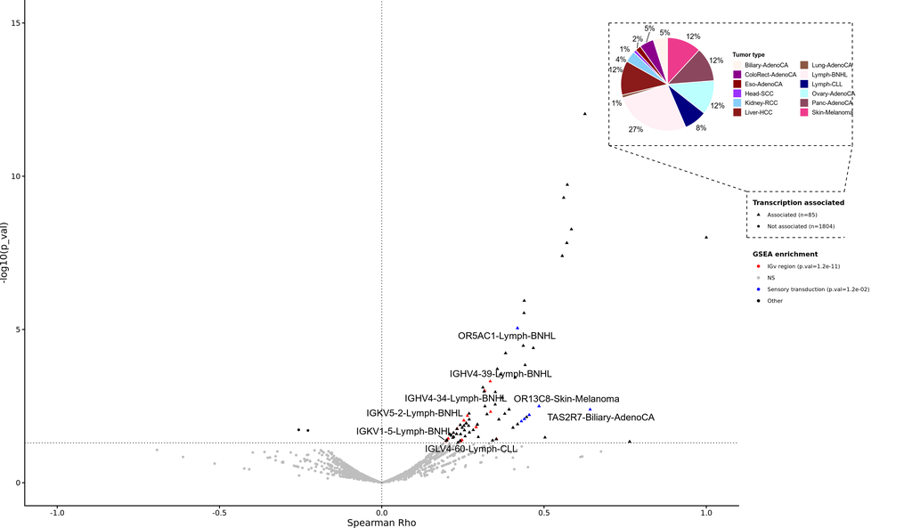

```r
pie_dat$prop<-round(pie_dat$prop,digits = 2)
pie_dat$prop_labl<-paste0(pie_dat$prop*100,"%")


color = grDevices::colors()[grep('gr(a|e)y', grDevices::colors(), invert = T)]
cols<-sample(color, nrow(pie_dat))

p_pie<-ggplot(pie_dat, aes(x = "", y = prop, fill = Tumor_type)) +
    geom_bar(width = 1, stat = "identity", color = "white") +
    coord_polar("y", start = 0)+
    geom_text_repel(aes(y = lab.ypos, label = prop_labl,x = 1.5), color = "black",
                    segment.size = .4,nudge_x = .05,
                    show.legend = FALSE)+
    theme_void()+scale_fill_manual(values = cols,name="Tumor type")+theme(legend.title = element_text(size = 9,face="bold"),legend.key.size = unit(0.5, "cm"),legend.text = element_text(size = 9))+ guides(fill = guide_legend(ncol = 2))



###Insert inset
##Merge inside the other
##Grab
# called a "grop" in Grid terminology
xbp_grob <- ggplotGrob(p_pie)

p_enrich_transcription2<-p_enrich_transcription + annotation_custom(grob = xbp_grob, xmin = 0, xmax = 2.15,  ymin = 11, ymax = 15)+annotate("segment", x=0.7, y=15, xend=1.45, yend=15,col="black", linetype="dashed")+annotate("segment", x=0.7, y=11, xend=1.45, yend=11,col="black", linetype="dashed")+annotate("segment", x=0.7, y=15, xend=.7, yend=11,col="black", linetype="dashed")+annotate("segment", x=1.45, y=15, xend=1.45, yend=11,col="black", linetype="dashed")+annotate("segment", x=1.125, y=9.5, xend=1.425, yend=9.5,col="black", linetype="dashed")+annotate("segment", x=1.125, y=8, xend=1.425, yend=8,col="black", linetype="dashed")+annotate("segment", x=1.125, y=8, xend=1.125, yend=9.5,col="black", linetype="dashed")+annotate("segment", x=1.425, y=8, xend=1.425, yend=9.5,col="black", linetype="dashed")+annotate("segment", x=.7, y=11, xend=1.125, yend=9.5,col="black", linetype="dashed")+annotate("segment", x=1.425, y=9.5, xend=1.45, yend=11,col="black", linetype="dashed")+coord_cartesian(xlim = c(-1, 1), clip="off",ylim=c(0,15))



p_enrich_transcription2+theme(plot.margin = unit(c(0,2,0,0), "cm"))
```

```r
########
#####Plot for "pipeline"
```